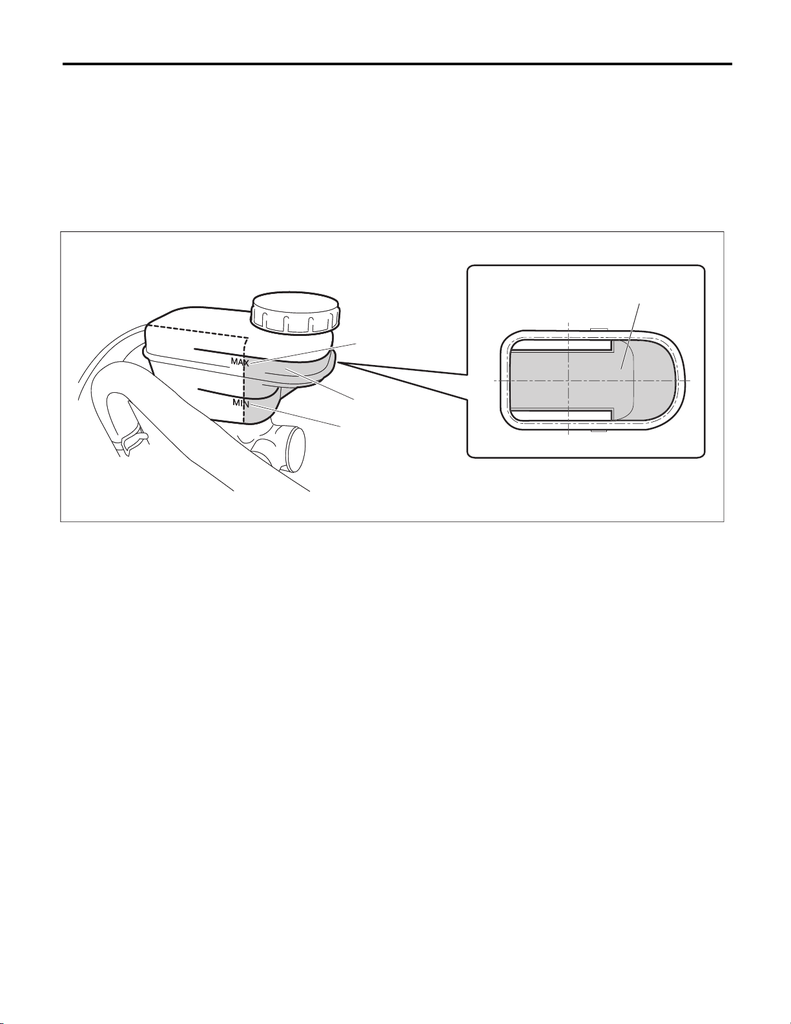

BR-64

Brake Fluid

BRAKE

10.Brake Fluid

A: INSPECTION

1) Check that the amount of brake fluid is between the lines of “MIN” (a) and “MAX” (b) from a straight view

or within 90° to the right and left forward.

If out of the specified range, refill with brake fluid (c) or drain it.

If the brake fluid level is close to “MIN”, check the brake pad for wear and refill with brake fluid.

CAUTION:

Always check the level using the specified direction because there is a partition in the reservoir tank.

2) Check the fluid for discoloration. If the fluid is extremely discolored, replace with the new fluid.

B: REPLACEMENT

CAUTION:

• Do not allow brake fluid to come in contact with the painted surface of the vehicle body. If it does,

wash off with water and wipe away completely.

• Prepare a container to catch grease or oil, etc. If any grease or oil spills, wipe it off and clean im-

mediately to prevent from penetrating into floor or flowing outside.

• Avoid mixing brake fluid of different brands to prevent fluid performance from degrading.

• Be careful not to allow dirt or dust to enter the reservoir tank.

NOTE:

• During the operation, keep the reservoir tank filled with brake fluid to prevent entry of air.

• Operate the brake pedal slowly.

• For convenience and safety, perform the work with 2 people.

• The required amount of brake fluid is approximately 500 mL (16.9 US fl oz, 17.6 Imp fl oz) for the entire

brake system.

1) Lift up the vehicle.

2) Remove all the wheels.

3) Drain brake fluid from the reservoir tank.

4) Refill the reservoir tank with recommended brake fluid.

Recommended brake fluid:

FMVSS No. 116, DOT3, or DOT4

Perform the same procedure as for bleeding the brake line, until new brake fluid comes out from vinyl tube.

<Ref. to BR-65, PROCEDURE, Air Bleeding.>

BR-00966

(a)

(b)

(c)

(c)

15WRX_STI_US_EN.book 64 ページ ２０１５年２月１３日 金曜日 午前１１時２０分